# More Tidymodels

Lecture 23

Dr. Colin Rundel

## Hotels Data

Original data from [Antonio, Almeida, and Nunes (2019)](https://doi.org/10.1016/j.dib.2018.11.126), see data dictionary [here](https://github.com/rfordatascience/tidytuesday/tree/master/data/2020/2020-02-11#data-dictionary)

```r
hotels = read_csv(
  'https://tidymodels.org/start/case-study/hotels.csv'
) |>
  mutate(
    across(where(is.character), as.factor)
  )
```

This version of the data is slightly modified from the original data - see this [gist](https://gist.github.com/topepo/05a74916c343e57a71c51d6bc32a21ce) for the cleanup details

## The data

```r
glimpse(hotels)
```

```
Rows: 50,000
Columns: 23
$ hotel                          <fct> City_Hotel, City_Hotel, Resort_Hotel, Resort_Hotel, Re…
$ lead_time                      <dbl> 217, 2, 95, 143, 136, 67, 47, 56, 80, 6, 130, 27, 16, …
$ stays_in_weekend_nights        <dbl> 1, 0, 2, 2, 1, 2, 0, 0, 0, 2, 1, 0, 1, 0, 1, 1, 1, 4, …
$ stays_in_week_nights           <dbl> 3, 1, 5, 6, 4, 2, 2, 3, 4, 2, 2, 1, 2, 2, 1, 1, 2, 7, …
$ adults                         <dbl> 2, 2, 2, 2, 2, 2, 2, 0, 2, 2, 2, 1, 2, 2, 2, 2, 2, 2, …
$ children                       <fct> none, none, none, none, none, none, children, children…
$ meal                           <fct> BB, BB, BB, HB, HB, SC, BB, BB, BB, BB, BB, BB, BB, BB…
$ country                        <fct> DEU, PRT, GBR, ROU, PRT, GBR, ESP, ESP, FRA, FRA, FRA,…
$ market_segment                 <fct> Offline_TA/TO, Direct, Online_TA, Online_TA, Direct, O…
$ distribution_channel           <fct> TA/TO, Direct, TA/TO, TA/TO, Direct, TA/TO, Direct, TA…
$ is_repeated_guest              <dbl> 0, 0, 0, 0, 0, 0, 0, 0, 0, 0, 0, 0, 0, 0, 0, 0, 0, 0, …
$ previous_cancellations         <dbl> 0, 0, 0, 0, 0, 0, 0, 0, 0, 0, 0, 0, 0, 0, 0, 0, 0, 0, …
$ previous_bookings_not_canceled <dbl> 0, 0, 0, 0, 0, 0, 0, 0, 0, 0, 0, 0, 0, 0, 0, 0, 0, 0, …
$ reserved_room_type             <fct> A, D, A, A, F, A, C, B, D, A, A, D, A, D, A, A, D, A, …
$ assigned_room_type             <fct> A, K, A, A, F, A, C, A, D, A, D, D, A, D, A, A, D, A, …
$ booking_changes                <dbl> 0, 0, 2, 0, 0, 0, 0, 0, 0, 0, 0, 0, 0, 0, 0, 0, 0, 4, …
$ deposit_type                   <fct> No_Deposit, No_Deposit, No_Deposit, No_Deposit, No_Dep…
$ days_in_waiting_list           <dbl> 0, 0, 0, 0, 0, 0, 0, 0, 0, 0, 0, 0, 0, 0, 236, 0, 0, 0…
$ customer_type                  <fct> Transient-Party, Transient, Transient, Transient, Tran…
$ average_daily_rate             <dbl> 80.75, 170.00, 8.00, 81.00, 157.60, 49.09, 289.00, 82.…
$ required_car_parking_spaces    <fct> none, none, none, none, none, none, none, none, none, …
$ total_of_special_requests      <dbl> 1, 3, 2, 1, 4, 1, 1, 1, 1, 1, 0, 1, 0, 0, 0, 1, 0, 0, …
$ arrival_date                   <date> 2016-09-01, 2017-08-25, 2016-11-19, 2016-04-26, 2016-…
```

## Factors

```r
map_int(hotels, ~ length(levels(.x))) |> keep(~ .x > 0) |> sort()
```

```
                      hotel                    children required_car_parking_spaces
                          2                           2                           2
               deposit_type               customer_type                        meal
                          3                           4                           5
       distribution_channel              market_segment          reserved_room_type
                          5                           7                           9
         assigned_room_type                     country
                         10                         155
```

## The model

Our goal is to develop a model that is able to predict whether a booking will include children or not based on the other characteristics of the booking.

```r
hotels |>
  count(children) |>
  mutate(prop = n/sum(n))
```

```
# A tibble: 2 × 3
  children     n   prop
  <fct>    <int>  <dbl>
1 children  4038 0.0808
2 none     45962 0.919
```

## Stratifying the test/train split

```r
set.seed(123)

hotel_split = initial_split(
  hotels, strata = children
)

hotel_train = training(hotel_split)
hotel_test = testing(hotel_split)
```

```r
dim(hotel_train)
```

```
[1] 37500    23
```

```r
dim(hotel_test)
```

```
[1] 12500    23
```

```r
hotel_train |>
  count(children) |>
  mutate(prop = n/sum(n))
```

```
# A tibble: 2 × 3
  children     n   prop
  <fct>    <int>  <dbl>
1 children  3027 0.0807
2 none     34473 0.919
```

```r
hotel_test |>
  count(children) |>
  mutate(prop = n/sum(n))
```

```
# A tibble: 2 × 3
  children     n   prop
  <fct>    <int>  <dbl>
1 children  1011 0.0809
2 none     11489 0.919
```

## Logistic Regression model

```r
show_engines("logistic_reg")
```

```
# A tibble: 7 × 2
  engine    mode
  <chr>     <chr>
1 glm       classification
2 glmnet    classification
3 LiblineaR classification
4 spark     classification
5 keras     classification
6 stan      classification
7 brulee    classification
```

```r
lr_model = logistic_reg() |>
  set_engine("glm")
```

```r
translate(lr_model)
```

```
Logistic Regression Model Specification (classification)

Computational engine: glm

Model fit template:
stats::glm(formula = missing_arg(), data = missing_arg(), weights = missing_arg(),
    family = stats::binomial)
```

## Recipe

```r
lr_recipe = recipe(children ~ ., data = hotel_train) |>
  step_date(arrival_date, features = c("dow", "month"), label=TRUE) |>
  step_mutate(
    season = case_when(
      arrival_date_month %in% c(12, 1, 2) ~ "Winter",
      arrival_date_month %in% c(3, 4, 5) ~ "Spring",
      arrival_date_month %in% c(6, 7, 8) ~ "Summer",
      arrival_date_month %in% c(9, 10, 11) ~ "Fall"
    ) |>
      factor(levels = c("Winter", "Spring", "Summer", "Fall"))
  ) |>
  step_rm(arrival_date, arrival_date_month) |>
  step_rm(country) |>
  step_unknown(season) |>
  step_dummy(all_nominal_predictors()) |>
  step_zv(all_predictors())
```

```r
lr_recipe |>
  prep() |>
  bake(new_data = hotel_train)
```

```
# A tibble: 37,500 × 56
   lead_time stays_in_weekend_nights stays_in_week_nights adults is_repeated_guest
       <dbl>                   <dbl>                <dbl>  <dbl>             <dbl>
 1         2                       0                    1      2                 0
 2        95                       2                    5      2                 0
 3        67                       2                    2      2                 0
 4        47                       0                    2      2                 0
 5        56                       0                    3      0                 0
 6         6                       2                    2      2                 0
 7       130                       1                    2      2                 0
 8        27                       0                    1      1                 0
 9        46                       0                    2      2                 0
10       423                       1                    1      2                 0
# ℹ 37,490 more rows
# ℹ 51 more variables: previous_cancellations <dbl>, previous_bookings_not_canceled <dbl>,
#   booking_changes <dbl>, days_in_waiting_list <dbl>, average_daily_rate <dbl>,
#   total_of_special_requests <dbl>, children <fct>, hotel_Resort_Hotel <dbl>, meal_FB <dbl>,
#   meal_HB <dbl>, meal_SC <dbl>, meal_Undefined <dbl>, market_segment_Complementary <dbl>,
#   market_segment_Corporate <dbl>, market_segment_Direct <dbl>, market_segment_Groups <dbl>,
#   market_segment_Offline_TA.TO <dbl>, market_segment_Online_TA <dbl>, …
```

## Workflow

```r
( lr_work = workflow() |>
    add_model(lr_model) |>
    add_recipe(lr_recipe)
)
```

```
══ Workflow ════════════════════════════════════════════════
Preprocessor: Recipe
Model: logistic_reg()

── Preprocessor ────────────────────────────────────────────
7 Recipe Steps

• step_date()
• step_mutate()
• step_rm()
• step_rm()
• step_unknown()
• step_dummy()
• step_zv()

── Model ───────────────────────────────────────────────────
Logistic Regression Model Specification (classification)

Computational engine: glm
```

## Fit

```r
( lr_fit = lr_work |>
    fit(data = hotel_train) )
```

```
══ Workflow [trained] ══════════════════════════════════════
Preprocessor: Recipe
Model: logistic_reg()

── Preprocessor ────────────────────────────────────────────
7 Recipe Steps

• step_date()
• step_mutate()
• step_rm()
• step_rm()
• step_unknown()
• step_dummy()
• step_zv()

── Model ───────────────────────────────────────────────────

Call:  stats::glm(formula = ..y ~ ., family = stats::binomial, data = data)

Coefficients:
                        (Intercept)
                          17.121622
                          lead_time
                          -0.001154
            stays_in_weekend_nights
                           0.054898
               stays_in_week_nights
                          -0.038010
                             adults
                           0.645983
                  is_repeated_guest
                           0.429371
             previous_cancellations
                           0.245846
     previous_bookings_not_canceled
                           0.349532
                    booking_changes
                          -0.229274
               days_in_waiting_list
                           0.007381
```

[output cut: 14 more lines]

```
       market_segment_Complementary
                         -13.343605
           market_segment_Corporate
                         -12.231269
              market_segment_Direct
                         -13.002333
              market_segment_Groups
                         -11.959060
       market_segment_Offline_TA.TO
                         -13.358978
           market_segment_Online_TA
                         -13.489908

...
and 70 more lines.
```

## Tidy

```r
lr_fit |>
  broom::tidy() |>
  arrange(p.value) |>
  print(n=100)
```

```
# A tibble: 56 × 5
   term                estimate std.error statistic  p.value
   <chr>                  <dbl>     <dbl>     <dbl>    <dbl>
 1 average_daily_rate  -1.04e-2   5.14e-4 -20.3     1.40e-91
 2 total_of_special_r… -4.73e-1   2.64e-2 -17.9     9.93e-72
 3 assigned_room_type… -1.19e+0   7.79e-2 -15.3     9.80e-53
 4 reserved_room_type…  1.22e+0   8.91e-2  13.7     1.34e-42
 5 reserved_room_type… -2.57e+0   1.92e-1 -13.4     1.05e-40
 6 hotel_Resort_Hotel   8.28e-1   6.21e-2  13.3     1.65e-40
 7 adults               6.46e-1   4.97e-2  13.0     1.35e-38
 8 assigned_room_type… -1.77e+0   1.45e-1 -12.2     2.63e-34
 9 meal_SC              1.28e+0   1.26e-1  10.2     2.78e-24
10 reserved_room_type… -2.25e+0   2.27e-1  -9.92    3.45e-23
11 booking_changes     -2.29e-1   2.54e-2  -9.03    1.66e-19
12 reserved_room_type… -1.53e+0   1.79e-1  -8.53    1.42e-17
```

[output cut: 44 more lines]

## Logistic regression predictions

```r
( lr_train_perf = lr_fit |>
    augment(new_data = hotel_train) |>
    select(children, starts_with(".pred")) )
```

```
# A tibble: 37,500 × 4
   children .pred_class .pred_children .pred_none
   <fct>    <fct>                <dbl>      <dbl>
 1 none     none               0.0709      0.929
 2 none     none               0.0332      0.967
 3 none     none               0.00982     0.990
 4 children children           0.920       0.0798
 5 children none               0.441       0.559
 6 children none               0.115       0.885
 7 none     none               0.0656      0.934
 8 none     none               0.0931      0.907
 9 none     none               0.0220      0.978
10 none     none               0.0539      0.946
# ℹ 37,490 more rows
```

```r
( lr_test_perf = lr_fit |>
    augment(new_data = hotel_test) |>
    select(children, starts_with(".pred")) )
```

```
# A tibble: 12,500 × 4
   children .pred_class .pred_children .pred_none
   <fct>    <fct>                <dbl>      <dbl>
 1 none     none              0.0194        0.981
 2 none     none              0.0221        0.978
 3 none     children          0.723         0.277
 4 none     none              0.0721        0.928
 5 none     none              0.000687      0.999
 6 none     none              0.000665      0.999
 7 none     none              0.111         0.889
 8 none     none              0.0464        0.954
 9 none     none              0.0652        0.935
10 none     none              0.103         0.897
# ℹ 12,490 more rows
```

## Performance metrics (within-sample)

```r
conf_mat(lr_train_perf, children, .pred_class)
```

```
          Truth
Prediction children  none
  children     1059   418
  none         1968 34055
```

```r
accuracy(lr_train_perf, children, .pred_class)
```

```
# A tibble: 1 × 3
  .metric  .estimator .estimate
  <chr>    <chr>          <dbl>
1 accuracy binary         0.936
```

```r
precision(lr_train_perf, children, .pred_class)
```

```
# A tibble: 1 × 3
  .metric   .estimator .estimate
  <chr>     <chr>          <dbl>
1 precision binary         0.717
```

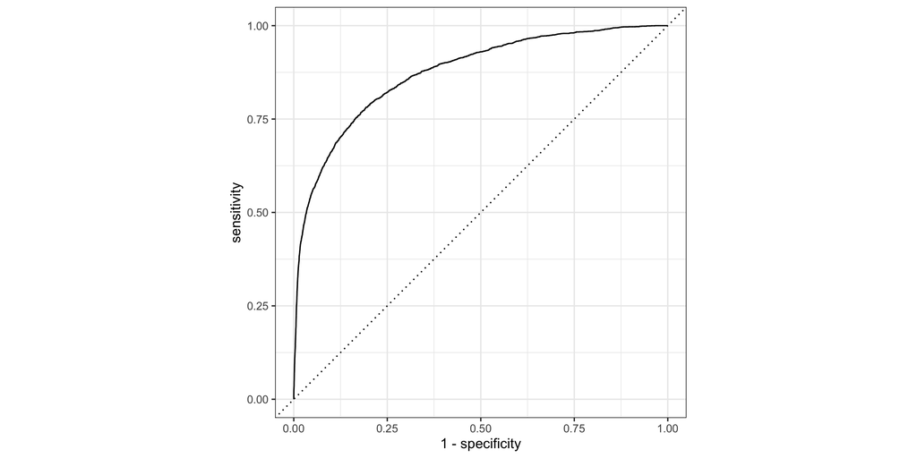

```r
yardstick::roc_curve(lr_train_perf, children, .pred_children) |>
  autoplot()
```

```r
roc_auc(lr_train_perf, children, .pred_children)
```

```
# A tibble: 1 × 3
  .metric .estimator .estimate
  <chr>   <chr>          <dbl>
1 roc_auc binary         0.874
```

## Performance metrics (out-of-sample)

```r
conf_mat(lr_test_perf, children, .pred_class)
```

```
          Truth
Prediction children  none
  children      341   134
  none          670 11355
```

```r
accuracy(lr_test_perf, children, .pred_class)
```

```
# A tibble: 1 × 3
  .metric  .estimator .estimate
  <chr>    <chr>          <dbl>
1 accuracy binary         0.936
```

```r
precision(lr_test_perf, children, .pred_class)
```

```
# A tibble: 1 × 3
  .metric   .estimator .estimate
  <chr>     <chr>          <dbl>
1 precision binary         0.718
```

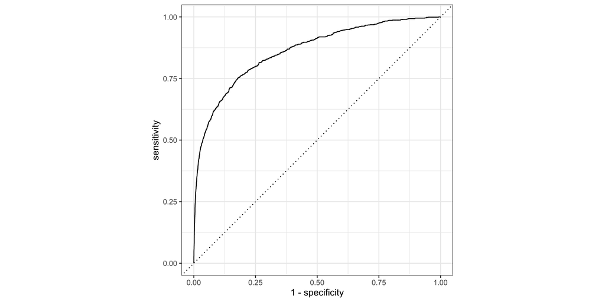

```r
yardstick::roc_curve(lr_test_perf, children, .pred_children) |>
  autoplot()
```

```r
roc_auc(lr_test_perf, children, .pred_children)
```

```
# A tibble: 1 × 3
  .metric .estimator .estimate
  <chr>   <chr>          <dbl>
1 roc_auc binary         0.861
```

## Combining ROC curves

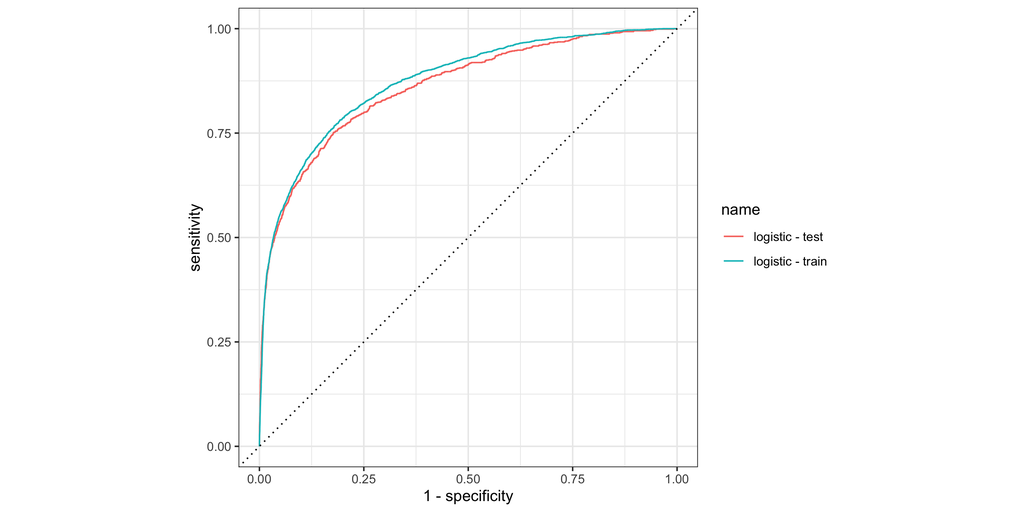

```r
bind_rows(
  lr_train_perf |> mutate(name = "logistic - train"),
  lr_test_perf |> mutate(name = "logistic - test")
) |>
  group_by(name) |>
  yardstick::roc_curve(children, .pred_children) |>
  autoplot()
```

## Metric sets

```r
(hotel_metrics = metric_set(accuracy, roc_auc, sensitivity, specificity, brier_class))
```

```
A metric set, consisting of:
- `accuracy()`, a class metric          | direction: maximize
- `roc_auc()`, a probability metric     | direction: maximize
- `sensitivity()`, a class metric       | direction: maximize
- `specificity()`, a class metric       | direction: maximize
- `brier_class()`, a probability metric | direction: minimize
```

```r
hotel_metrics(lr_train_perf, truth = children, estimate = .pred_class, .pred_children)
```

```
# A tibble: 5 × 3
  .metric     .estimator .estimate
  <chr>       <chr>          <dbl>
1 accuracy    binary        0.936
2 sensitivity binary        0.350
3 specificity binary        0.988
4 roc_auc     binary        0.874
5 brier_class binary        0.0519
```

# Lasso

## Lasso Model

For this we will be using the `glmnet` package which supports fitting lasso, ridge and elastic net models.

$$\min _{\beta_0, \beta} \frac{1}{N} \sum_{i=1}^N w_i l\left(y_i, \beta_0+\beta^T x_i\right)+\lambda\left[(1-\alpha)\|\beta\|{ }_2^2 / 2+\alpha\|\beta\|_1\right],$$

```r
lasso_model = logistic_reg(penalty = tune(), mixture = 1) |>
  set_engine("glmnet")
```

- `mixture` ($\alpha$) determines the type of model fit
  - `1` for Lasso,
  - `0` for Ridge,
  - other for elastic net.
- `penalty` ($\lambda$) is the penalty term for coefficient size.

```r
lasso_model |>
  hardhat::extract_parameter_set_dials()
```

```
Collection of 1 parameters for tuning
```

```
 identifier    type    object
    penalty penalty nparam[+]
```

```r
lasso_model |>
  translate()
```

```
Logistic Regression Model Specification (classification)

Main Arguments:
  penalty = tune()
  mixture = 1

Computational engine: glmnet

Model fit template:
glmnet::glmnet(x = missing_arg(), y = missing_arg(), weights = missing_arg(),
    alpha = 1, family = "binomial")
```

## Lasso Recipe

Lasso (and Ridge) models are sensitive to the scale of the model features. As such it is necessary to normalize all features before fitting the model.

```r
lasso_recipe = lr_recipe |>
  step_normalize(all_predictors())
```

```r
lasso_recipe |>
  prep() |>
  bake(new_data = hotel_train)
```

```
# A tibble: 37,500 × 56
   lead_time stays_in_weekend_nights stays_in_week_nights adults is_repeated_guest
       <dbl>                   <dbl>                <dbl>  <dbl>             <dbl>
 1    -0.858                 -0.938                -0.767  0.337            -0.213
 2     0.160                  1.09                  1.32   0.337            -0.213
 3    -0.146                  1.09                 -0.245  0.337            -0.213
 4    -0.365                 -0.938                -0.245  0.337            -0.213
 5    -0.267                 -0.938                 0.278 -3.59             -0.213
 6    -0.814                  1.09                 -0.245  0.337            -0.213
 7     0.544                  0.0735               -0.245  0.337            -0.213
 8    -0.584                 -0.938                -0.767 -1.63             -0.213
 9    -0.376                 -0.938                -0.245  0.337            -0.213
10     3.75                   0.0735               -0.767  0.337            -0.213
# ℹ 37,490 more rows
# ℹ 51 more variables: previous_cancellations <dbl>, previous_bookings_not_canceled <dbl>,
#   booking_changes <dbl>, days_in_waiting_list <dbl>, average_daily_rate <dbl>,
#   total_of_special_requests <dbl>, children <fct>, hotel_Resort_Hotel <dbl>, meal_FB <dbl>,
#   meal_HB <dbl>, meal_SC <dbl>, meal_Undefined <dbl>, market_segment_Complementary <dbl>,
#   market_segment_Corporate <dbl>, market_segment_Direct <dbl>, market_segment_Groups <dbl>,
#   market_segment_Offline_TA.TO <dbl>, market_segment_Online_TA <dbl>, …
```

## Lasso workflow

```r
( lasso_work = workflow() |>
    add_model(lasso_model) |>
    add_recipe(lasso_recipe)
)
```

```
══ Workflow ═════════════════════════════════════════════════════════════════════════
Preprocessor: Recipe
Model: logistic_reg()

── Preprocessor ─────────────────────────────────────────────────────────────────────
8 Recipe Steps

• step_date()
• step_mutate()
• step_rm()
• step_rm()
• step_unknown()
• step_dummy()
• step_zv()
• step_normalize()

── Model ────────────────────────────────────────────────────────────────────────────
Logistic Regression Model Specification (classification)

Main Arguments:
  penalty = tune()
  mixture = 1

Computational engine: glmnet
```

## v-folds for hyperparameter tuning

```r
( hotel_vf = rsample::vfold_cv(hotel_train, v=5, strata = children) )
```

```
#  5-fold cross-validation using stratification
# A tibble: 5 × 2
  splits               id
  <list>               <chr>
1 <split [30000/7500]> Fold1
2 <split [30000/7500]> Fold2
3 <split [30000/7500]> Fold3
4 <split [30000/7500]> Fold4
5 <split [30000/7500]> Fold5
```

## grid search

```r
( lasso_grid = lasso_work |>
    tune_grid(
      hotel_vf,
      grid = tibble(
        penalty = 10^seq(-4, -1, length.out = 10)
      ),
      control = control_grid(save_pred = TRUE),
      metrics = metric_set(roc_auc)
    )
)
```

```
# Tuning results
# 5-fold cross-validation using stratification
# A tibble: 5 × 5
  splits               id    .metrics .notes   .predictions
  <list>               <chr> <list>   <list>   <list>
1 <split [30000/7500]> Fold1 <tibble> <tibble> <tibble>
2 <split [30000/7500]> Fold2 <tibble> <tibble> <tibble>
3 <split [30000/7500]> Fold3 <tibble> <tibble> <tibble>
4 <split [30000/7500]> Fold4 <tibble> <tibble> <tibble>
5 <split [30000/7500]> Fold5 <tibble> <tibble> <tibble>
```

## Results

```r
lasso_grid |>
  collect_metrics()
```

```
# A tibble: 10 × 7
    penalty .metric .estimator  mean     n std_err
      <dbl> <chr>   <chr>      <dbl> <int>   <dbl>
 1 0.0001   roc_auc binary     0.871     5 0.00412
 2 0.000215 roc_auc binary     0.871     5 0.00419
 3 0.000464 roc_auc binary     0.871     5 0.00419
 4 0.001    roc_auc binary     0.871     5 0.00414
 5 0.00215  roc_auc binary     0.871     5 0.00399
 6 0.00464  roc_auc binary     0.865     5 0.00361
 7 0.01     roc_auc binary     0.853     5 0.00459
 8 0.0215   roc_auc binary     0.825     5 0.00684
 9 0.0464   roc_auc binary     0.798     5 0.00670
10 0.1      roc_auc binary     0.5       5 0
# ℹ 1 more variable: .config <chr>
```

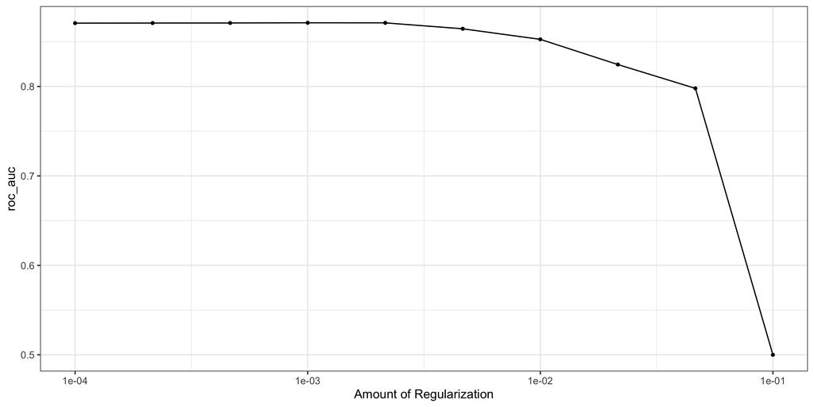

```r
lasso_grid |>
  autoplot()
```

## The “Best” models

```r
lasso_grid |>
  show_best(metric = "roc_auc", n=5)
```

```
# A tibble: 5 × 7
   penalty .metric .estimator  mean     n std_err .config
     <dbl> <chr>   <chr>      <dbl> <int>   <dbl> <chr>
1 0.001    roc_auc binary     0.871     5 0.00414 pre0_mod0…
2 0.00215  roc_auc binary     0.871     5 0.00399 pre0_mod0…
3 0.000464 roc_auc binary     0.871     5 0.00419 pre0_mod0…
4 0.000215 roc_auc binary     0.871     5 0.00419 pre0_mod0…
5 0.0001   roc_auc binary     0.871     5 0.00412 pre0_mod0…
```

```r
( lasso_best = lasso_grid |>
    select_best() )
```

```
# A tibble: 1 × 2
  penalty .config
    <dbl> <chr>
1   0.001 pre0_mod04_post0
```

## Extracting predictions

Since we used `control_grid(save_pred = TRUE)` in `tune_grid()` we can recover the predictions for the out-of-sample values for each fold

```r
( lasso_train_perf = lasso_grid |>
    collect_predictions(parameters = lasso_best) )
```

```
# A tibble: 37,500 × 7
   .pred_children .pred_none id    children  .row penalty
            <dbl>      <dbl> <chr> <fct>    <int>   <dbl>
 1        0.0338       0.966 Fold1 none         2   0.001
 2        0.0116       0.988 Fold1 none         3   0.001
 3        0.0103       0.990 Fold1 none        17   0.001
 4        0.0827       0.917 Fold1 children    22   0.001
 5        0.839        0.161 Fold1 children    27   0.001
 6        0.0357       0.964 Fold1 none        28   0.001
 7        0.0103       0.990 Fold1 none        30   0.001
 8        0.0432       0.957 Fold1 none        38   0.001
 9        0.0204       0.980 Fold1 none        44   0.001
10        0.00831      0.992 Fold1 none        49   0.001
# ℹ 37,490 more rows
# ℹ 1 more variable: .config <chr>
```

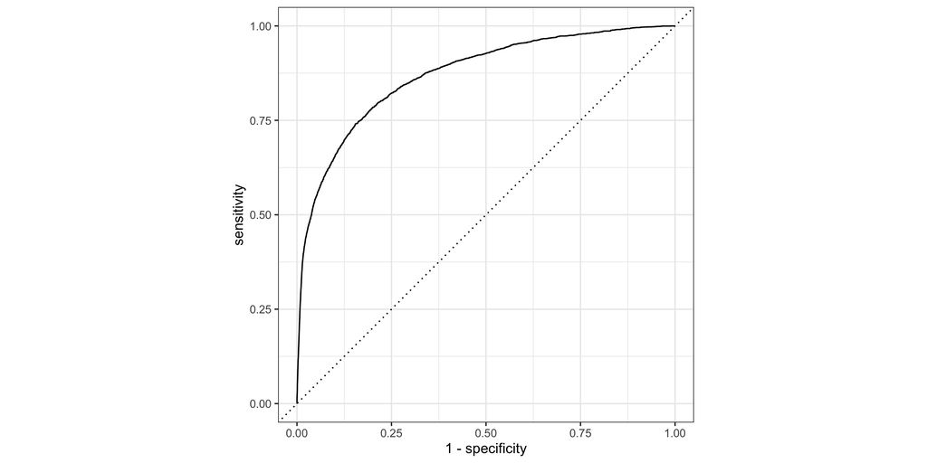

```r
lasso_train_perf |>
  roc_curve(children, .pred_children) |>
  autoplot()
```

```r
lasso_train_perf |>
  roc_auc(children, .pred_children)
```

```
# A tibble: 1 × 3
  .metric .estimator .estimate
  <chr>   <chr>          <dbl>
1 roc_auc binary         0.871
```

## Re-fitting

Typically with a tuned model we update the workflow (or model) with the optimal parameter values and then refit using the *complete* training data,

```r
lasso_work_tuned = finalize_workflow(
  lasso_work,
  lasso_best
)

( lasso_fit = lasso_work_tuned |>
    fit(data=hotel_train) )
```

```
══ Workflow [trained] ══════════════════════════════════════
Preprocessor: Recipe
Model: logistic_reg()

── Preprocessor ────────────────────────────────────────────
8 Recipe Steps

• step_date()
• step_mutate()
• step_rm()
• step_rm()
• step_unknown()
• step_dummy()
• step_zv()
• step_normalize()

── Model ───────────────────────────────────────────────────

Call:  glmnet::glmnet(x = maybe_matrix(x), y = y, family = "binomial",      alpha = ~1)

   Df  %Dev   Lambda
1   0  0.00 0.080750
2   1  2.56 0.073580
3   2  5.06 0.067040
4   3  7.45 0.061090
5   3  9.79 0.055660
6   4 12.07 0.050720
7   4 13.94 0.046210
8   5 15.37 0.042110
9   5 16.91 0.038360
10  5 18.09 0.034960
11  5 19.03 0.031850
12  6 19.94 0.029020
13  6 20.86 0.026440
14  6 21.61 0.024090
15  6 22.25 0.021950
16  7 22.95 0.020000
17  7 23.60 0.018230
18  8 24.16 0.016610
19  9 24.71 0.015130
```

[output cut: 15 more lines]

```
35 26 30.26 0.003415
36 27 30.52 0.003112
37 28 30.75 0.002835
38 31 30.95 0.002584
39 31 31.13 0.002354
40 32 31.29 0.002145
41 33 31.42 0.001954
42 37 31.54 0.001781
43 37 31.64 0.001623
44 38 31.73 0.001478
45 38 31.81 0.001347
46 39 31.87 0.001227

...
and 33 more lines.
```

## Test Performance (out-of-sample)

```r
lasso_test_perf = lasso_fit |>
  augment(new_data = hotel_test) |>
  select(children, starts_with(".pred"))
```

```r
conf_mat(lasso_test_perf, children, .pred_class)
```

```
          Truth
Prediction children  none
  children      331   120
  none          680 11369
```

```r
hotel_metrics(lasso_test_perf, truth = children, estimate = .pred_class, .pred_children)
```

```
# A tibble: 5 × 3
  .metric     .estimator .estimate
  <chr>       <chr>          <dbl>
1 accuracy    binary        0.936
2 sensitivity binary        0.327
3 specificity binary        0.990
4 roc_auc     binary        0.863
5 brier_class binary        0.0523
```

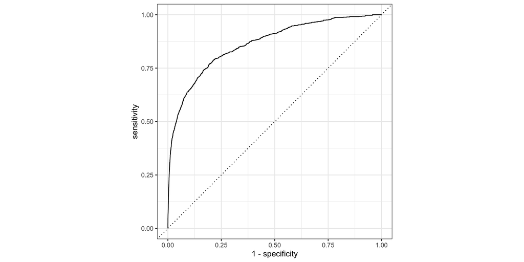

```r
yardstick::roc_curve(lasso_test_perf, children, .pred_children) |>
  autoplot()
```

## Comparing models

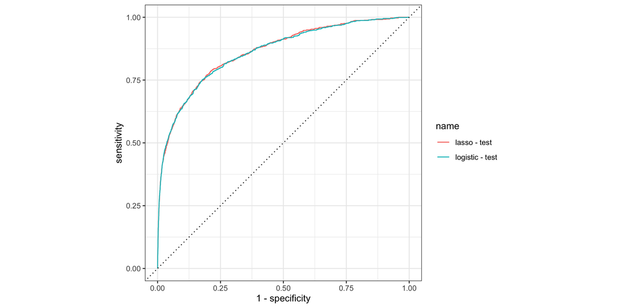

```r
bind_rows(
  lr_test_perf |> mutate(name = "logistic - test"),
  lasso_test_perf |> mutate(name = "lasso - test")
) |>
  group_by(name) |>
  yardstick::roc_curve(children, .pred_children) |>
  autoplot()
```

# Decision tree

## Decision tree models

```r
show_engines("decision_tree")
```

```
# A tibble: 5 × 2
  engine mode
  <chr>  <chr>
1 rpart  classification
2 rpart  regression
3 C5.0   classification
4 spark  classification
5 spark  regression
```

```r
dt_model = decision_tree(
  tree_depth = tune(),
  min_n = tune(),
  cost_complexity = tune()
) |>
  set_engine("rpart") |>
  set_mode("classification")
```

## Recipe & workflow

Same recipe as before but we skip dummy coding as it is not needed by rpart,

```r
dt_recipe = recipe(children ~ ., data = hotel_train) |>
  step_date(arrival_date, features = c("dow", "month"), label=TRUE) |>
  step_mutate(
    season = case_when(
      arrival_date_month %in% c(12, 1, 2) ~ "Winter",
      arrival_date_month %in% c(3, 4, 5) ~ "Spring",
      arrival_date_month %in% c(6, 7, 8) ~ "Summer",
      arrival_date_month %in% c(9, 10, 11) ~ "Fall"
    ) |>
      factor(levels = c("Winter", "Spring", "Summer", "Fall"))
  ) |>
  step_rm(arrival_date, arrival_date_month) |>
  step_rm(country)
```

```r
dt_work = workflow() |>
  add_model(dt_model) |>
  add_recipe(dt_recipe)
```

## Tuning

```r
( dt_grid = grid_regular(
    cost_complexity(),
    tree_depth(),
    min_n(),
    levels = 3
) )
```

```
# A tibble: 27 × 3
   cost_complexity tree_depth min_n
             <dbl>      <int> <int>
 1    0.0000000001          1     2
 2    0.00000316            1     2
 3    0.1                   1     2
 4    0.0000000001          8     2
 5    0.00000316            8     2
 6    0.1                   8     2
 7    0.0000000001         15     2
 8    0.00000316           15     2
 9    0.1                  15     2
10    0.0000000001          1    21
# ℹ 17 more rows
```

```r
dt_tune = dt_work |>
  tune_grid(
    hotel_vf,
    grid = dt_grid,
    control = control_grid(save_pred = TRUE),
    metrics = hotel_metrics
  )
```

How many decision tree models were fit by `tune_grid()`?

## Tuning results

```r
dt_tune |>
  collect_metrics() |>
  arrange(desc(mean))
```

```
# A tibble: 135 × 9
   cost_complexity tree_depth min_n .metric .estimator  mean
             <dbl>      <int> <int> <chr>   <chr>      <dbl>
 1    0.0000000001          8    40 specif… binary     0.987
 2    0.00000316            8    40 specif… binary     0.987
 3    0.0000000001          8    21 specif… binary     0.987
 4    0.00000316            8    21 specif… binary     0.987
 5    0.0000000001          8     2 specif… binary     0.986
 6    0.00000316            8     2 specif… binary     0.986
 7    0.0000000001         15    40 specif… binary     0.984
 8    0.00000316           15    40 specif… binary     0.984
 9    0.1                   1     2 specif… binary     0.979
10    0.1                   1    21 specif… binary     0.979
# ℹ 125 more rows
# ℹ 3 more variables: n <int>, std_err <dbl>, .config <chr>
```

## “Best” parameters

```r
dt_tune |>
  show_best(metric = "roc_auc")
```

```
# A tibble: 5 × 9
  cost_complexity tree_depth min_n .metric
            <dbl>      <int> <int> <chr>
1    0.0000000001         15    21 roc_auc
2    0.00000316           15    21 roc_auc
3    0.0000000001         15    40 roc_auc
4    0.00000316           15    40 roc_auc
5    0.0000000001          8     2 roc_auc
# ℹ 5 more variables: .estimator <chr>,
#   mean <dbl>, n <int>, std_err <dbl>,
#   .config <chr>
```

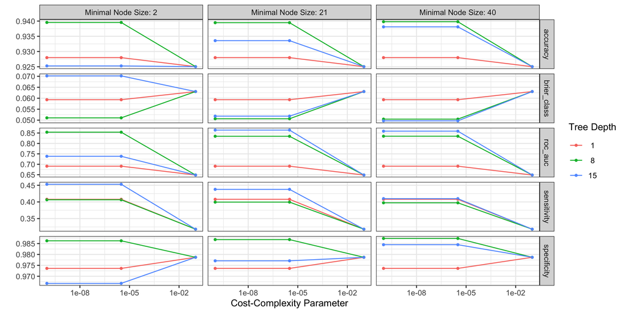

```r
autoplot(dt_tune)
```

## Re-fitting

```r
(dt_best = dt_tune |>
  select_best(metric = "roc_auc"))
```

```
# A tibble: 1 × 4
  cost_complexity tree_depth min_n .config
            <dbl>      <int> <int> <chr>
1    0.0000000001         15    21 pre0_mod08_post0
```

```r
dt_work_tuned = finalize_workflow(
  dt_work,
  dt_best
)

( dt_fit = dt_work_tuned |>
    fit(data=hotel_train))
```

```
══ Workflow [trained] ══════════════════════════════════════
Preprocessor: Recipe
Model: decision_tree()

── Preprocessor ────────────────────────────────────────────
4 Recipe Steps

• step_date()
• step_mutate()
• step_rm()
• step_rm()

── Model ───────────────────────────────────────────────────
n= 37500

node), split, n, loss, yval, (yprob)
      * denotes terminal node

    1) root 37500 3027 none (0.080720000 0.919280000)
      2) reserved_room_type=C,F,G,H 2147  910 children (0.576152771 0.423847229)
        4) market_segment=Online_TA 1218  350 children (0.712643678 0.287356322)
          8) average_daily_rate>=140.715 890  196 children (0.779775281 0.220224719)
           16) adults< 2.5 769  139 children (0.819245774 0.180754226)
             32) booking_changes< 0.5 581   77 children (0.867469880 0.132530120)
               64) hotel=City_Hotel 363   26 children (0.928374656 0.071625344)
                128) reserved_room_type=F 311   15 children (0.951768489 0.048231511) *
                129) reserved_room_type=G 52   11 children (0.788461538 0.211538462)
                  258) lead_time>=38 23    0 children (1.000000000 0.000000000) *
                  259) lead_time< 38 29   11 children (0.620689655 0.379310345)
                    518) arrival_date_dow=Mon,Tue,Wed 9    0 children (1.000000000 0.000000000) *
                    519) arrival_date_dow=Sun,Thu,Fri,Sat 20    9 none (0.450000000 0.550000000) *
               65) hotel=Resort_Hotel 218   51 children (0.766055046 0.233944954)
                130) assigned_room_type=C,D,G,H,I 183   24 children (0.868852459 0.131147541)
                  260) average_daily_rate>=253.5 41    0 children (1.000000000 0.000000000) *
                  261) average_daily_rate< 253.5 142   24 children (0.830985915 0.169014085)
                    522) lead_time>=0.5 135   21 children (0.844444444 0.155555556)
                     1044) average_daily_rate< 161.93 29    1 children (0.965517241 0.034482759) *
                     1045) average_daily_rate>=161.93 106   20 children (0.811320755 0.188679245)
                       2090) average_daily_rate>=175.855 81   11 children (0.864197531 0.135802469) *
                       2091) average_daily_rate< 175.855 25    9 children (0.640000000 0.360000000)
```

[output cut: 11 more lines]

```
                134) reserved_room_type=C,F,H 111   36 children (0.675675676 0.324324324)
                  268) arrival_date_dow=Mon,Tue,Fri 43    9 children (0.790697674 0.209302326) *
                  269) arrival_date_dow=Sun,Wed,Thu,Sat 68   27 children (0.602941176 0.397058824)
                    538) assigned_room_type=E,F,G,H 54   18 children (0.666666667 0.333333333)
                     1076) average_daily_rate< 233.25 38    9 children (0.763157895 0.236842105) *
                     1077) average_daily_rate>=233.25 16    7 none (0.437500000 0.562500000) *
                    539) assigned_room_type=B,C,K 14    5 none (0.357142857 0.642857143) *
                135) reserved_room_type=G 41   17 none (0.414634146 0.585365854)
                  270) arrival_date_dow=Tue,Wed,Fri,Sat 24   10 children (0.583333333 0.416666667)
                    540) lead_time< 23.5 8    1 children (0.875000000 0.125000000) *
                    541) lead_time>=23.5 16    7 none (0.437500000 0.562500000) *
                  271) arrival_date_dow=Sun,Mon,Thu 17    3 none (0.176470588 0.823529412) *

...
and 468 more lines.
```

## Model extraction

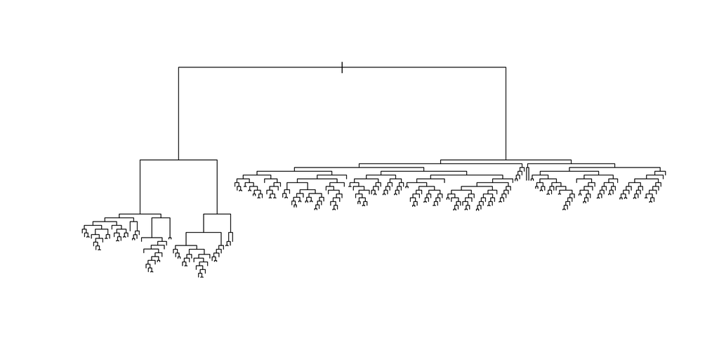

```r
dt_fit |>
  hardhat::extract_fit_engine() |>
  plot()
```

## Test Performance (out-of-sample)

```r
dt_test_perf = dt_fit |>
  augment(new_data = hotel_test) |>
  select(children, starts_with(".pred"))
```

```r
conf_mat(dt_test_perf, children, .pred_class)
```

```
          Truth
Prediction children  none
  children      450   268
  none          561 11221
```

```r
hotel_metrics(dt_test_perf, truth = children, estimate = .pred_class, .pred_children)
```

```
# A tibble: 5 × 3
  .metric     .estimator .estimate
  <chr>       <chr>          <dbl>
1 accuracy    binary        0.934
2 sensitivity binary        0.445
3 specificity binary        0.977
4 roc_auc     binary        0.862
5 brier_class binary        0.0512
```

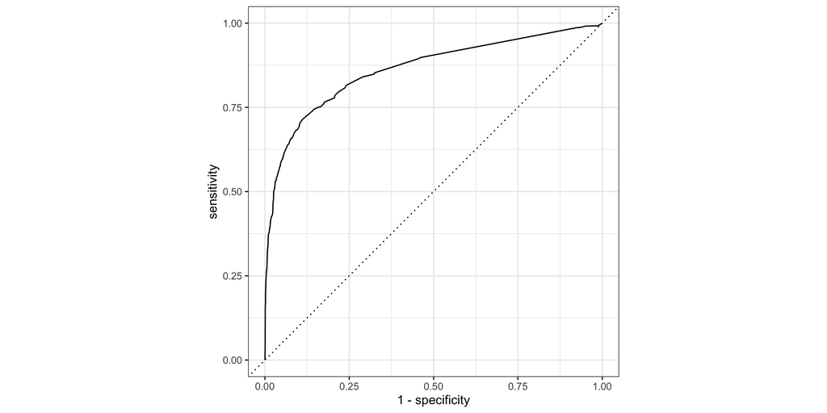

```r
yardstick::roc_curve(dt_test_perf, children, .pred_children) |>
  autoplot()
```

## Comparing models

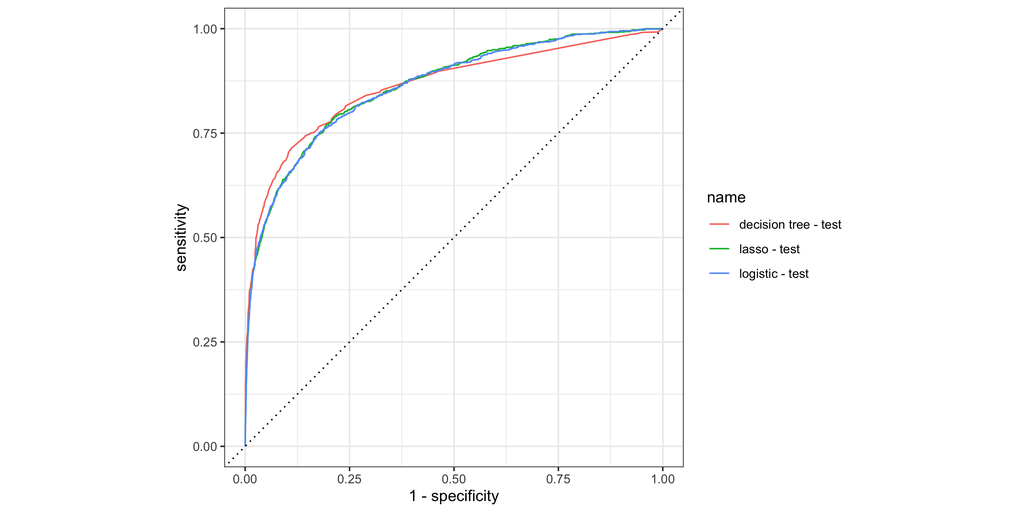

```r
bind_rows(
  lr_test_perf |> mutate(name = "logistic - test"),
  lasso_test_perf |> mutate(name = "lasso - test"),
  dt_test_perf |> mutate(name = "decision tree - test")
) |>
  group_by(name) |>
  yardstick::roc_curve(children, .pred_children) |>
  autoplot()
```

# Random Forest

## Random forest models

```r
show_engines("rand_forest")
```

```
# A tibble: 9 × 2
  engine       mode
  <chr>        <chr>
1 ranger       classification
2 ranger       regression
3 randomForest classification
4 randomForest regression
5 spark        classification
6 spark        regression
7 grf          classification
8 grf          regression
9 grf          quantile regression
```

```r
rf_model = rand_forest(mtry = tune(), min_n = tune(), trees = 100) |>
  set_engine("ranger", num.threads = 1) |>
  set_mode("classification")
```

## Recipe & workflow

We again skip dummy coding in the recipe as it is not needed by ranger,

```r
rf_recipe = dt_recipe
```

```r
rf_work = workflow() |>
  add_model(rf_model) |>
  add_recipe(rf_recipe)
```

## Tuning - automatic grid search

```r
rf_tune = rf_work |>
  tune_grid(
    hotel_vf,
    grid = 10,
    control = control_grid(save_pred = TRUE),
    metrics = metric_set(roc_auc)
  )
```

```r
rf_tune |>
  collect_metrics() |>
  arrange(desc(mean))
```

```
# A tibble: 10 × 8
    mtry min_n .metric .estimator  mean     n std_err
   <int> <int> <chr>   <chr>      <dbl> <int>   <dbl>
 1     3    31 roc_auc binary     0.911     5 0.00406
 2     5     2 roc_auc binary     0.911     5 0.00445
 3     8    18 roc_auc binary     0.909     5 0.00417
 4    10    35 roc_auc binary     0.907     5 0.00414
 5    15    23 roc_auc binary     0.904     5 0.00404
 6    17    40 roc_auc binary     0.904     5 0.00424
 7    12     6 roc_auc binary     0.903     5 0.00401
 8    22    27 roc_auc binary     0.900     5 0.00428
 9    19    10 roc_auc binary     0.900     5 0.00339
10     1    14 roc_auc binary     0.869     5 0.00412
# ℹ 1 more variable: .config <chr>
```

## “Best” parameters

```r
rf_tune |>
  show_best(metric = "roc_auc")
```

```
# A tibble: 5 × 8
   mtry min_n .metric .estimator  mean     n
  <int> <int> <chr>   <chr>      <dbl> <int>
1     3    31 roc_auc binary     0.911     5
2     5     2 roc_auc binary     0.911     5
3     8    18 roc_auc binary     0.909     5
4    10    35 roc_auc binary     0.907     5
5    15    23 roc_auc binary     0.904     5
# ℹ 2 more variables: std_err <dbl>,
#   .config <chr>
```

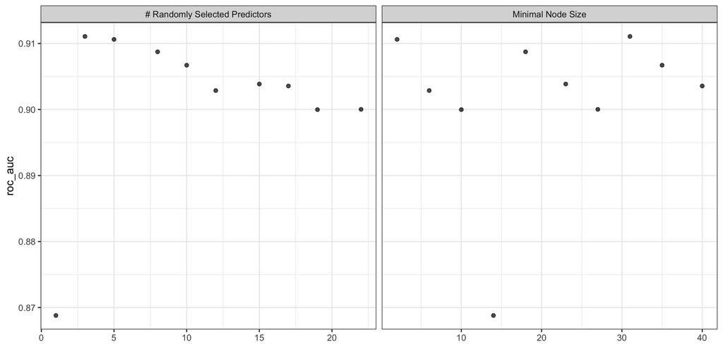

```r
autoplot(rf_tune)
```

## Re-fitting

```r
rf_best = rf_tune |>
  select_best(metric = "roc_auc")
```

```r
rf_work_tuned = finalize_workflow(
  rf_work,
  rf_best
)

( rf_fit = rf_work_tuned |>
    fit(data=hotel_train) )
```

```
══ Workflow [trained] ══════════════════════════════════════
Preprocessor: Recipe
Model: rand_forest()

── Preprocessor ────────────────────────────────────────────
4 Recipe Steps

• step_date()
• step_mutate()
• step_rm()
• step_rm()

── Model ───────────────────────────────────────────────────
Ranger result

Call:
 ranger::ranger(x = maybe_data_frame(x), y = y, mtry = min_cols(~3L,      x), num.trees = ~100, min.node.size = min_rows(~31L, x),      num.threads = ~1, verbose = FALSE, seed = sample.int(10^5,          1), probability = TRUE)

Type:                             Probability estimation
Number of trees:                  100
Sample size:                      37500
Number of independent variables:  22
Mtry:                             3
Target node size:                 31
Variable importance mode:         none
Splitrule:                        gini
OOB prediction error (Brier s.):  0.04686732
```

## Test Performance (out-of-sample)

```r
rf_test_perf = rf_fit |>
  augment(new_data = hotel_test) |>
  select(children, starts_with(".pred"))
```

```r
conf_mat(rf_test_perf, children, .pred_class)
```

```
          Truth
Prediction children  none
  children      324    59
  none          687 11430
```

```r
hotel_metrics(rf_test_perf, truth = children, estimate = .pred_class, .pred_children)
```

```
# A tibble: 5 × 3
  .metric     .estimator .estimate
  <chr>       <chr>          <dbl>
1 accuracy    binary        0.940
2 sensitivity binary        0.320
3 specificity binary        0.995
4 roc_auc     binary        0.912
5 brier_class binary        0.0469
```

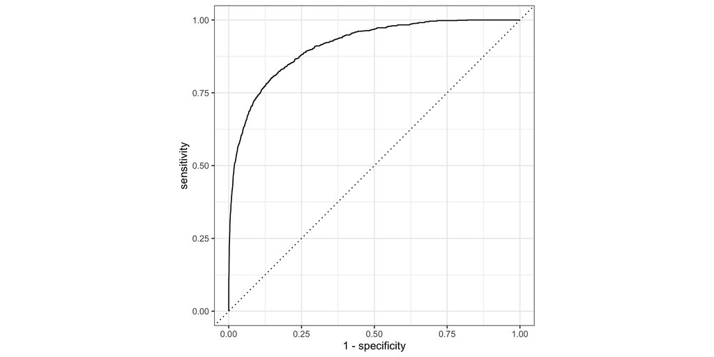

```r
yardstick::roc_curve(rf_test_perf, children, .pred_children) |>
  autoplot()
```

## Comparing models

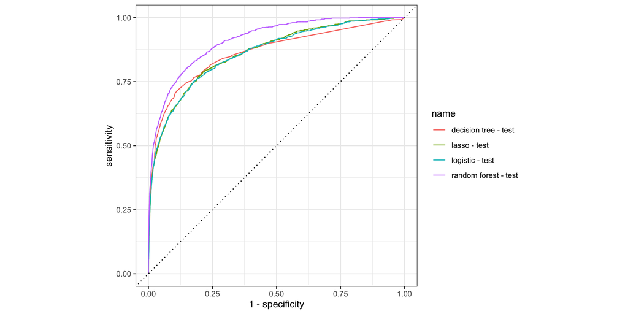

```r
bind_rows(
  lr_test_perf |> mutate(name = "logistic - test"),
  lasso_test_perf |> mutate(name = "lasso - test"),
  dt_test_perf |> mutate(name = "decision tree - test"),
  rf_test_perf |> mutate(name = "random forest - test")
) |>
  group_by(name) |>
  yardstick::roc_curve(children, .pred_children) |>
  autoplot()
```